# Species Distribution Modelling with MaxEnt in R

## Chapter 3 Absence and background points

If we have a large dataset with presence/absence and well designed survey, we should apply a method that can use these data (GLM framework a.k.a the classical approach).

Presence only data still can be used in a method that needs absence data. We substitute absence data with background data. However, background data is not equal with pseudo-absence data.

It’s safer to define backround data is used to characterise (the probability density of) environments in the study region, rather than attempting to guess at absence locations.

Please mind that absence data can be biased and incomplete.

> Absence data are plagued by issues of detection probability (Wintle et al. , 2004; MacKenzie, 2005) so that even presence-absence data may not yield a good estimate of prevalence, see 10.1111/j.1472-4642.2010.00725.x

### 3.1 Generating background points

```r
#get the predetermined file names
files <- list.files(path=paste(system.file(package="dismo"), '/ex',sep=''), pattern='grd', full.names=TRUE )
mask <- raster(files[1]) #apply the first file to create a RasterLayer
set.seed(1963) # set seed to assure that the examples will always have the same random sample
bg<- randomPoints(mask,500) # select 500 random points; the points will lie on grids that have values, no points will be generated on NAs
#inspect the results by plotting:
par(mfrow=c(1,2))
plot(!is.na(mask), legend=FALSE)
points(bg, cex=0.5)
```

```r
# we repeat the samplin, but limit the area of sampling using a spatial extent
e<-extent(-80, -53, -39, -22)
bg2<-randomPoints(mask, 50, ext=e)
plot(!is.na(mask), legend=FALSE)
plot(e, add=TRUE, col='red')
```

[output not shown]

[figure not shown]

```r
points(bg2, cex=0.5)
```

### 3.2 Generating pseudo-absence points

VanDerWal et al. (2009) sampled withn a radius of presence points to sample ; basically this is a more restricted area of background points.

```r
ac<-read_csv("./data/acaule.csv")
#convert the data.frame into a SpatialPointsDataFrame
coordinates(ac)<-~longitude-latitude
projection(ac)<- CRS('+proj=longlat +datum=WGS84')
# circles with a radius of 50 km
x <- circles(ac, d=50000, lonlat=TRUE)
pol <- polygons(x)
# sample randomly from all circles
samp1 <- spsample(pol, 250, type='random', iter=25)
# get unique cells
cells <- cellFromXY(mask, samp1)
length(cells)
```

```
[1] 250
```

```r
cells <- unique(cells)
length(cells)
```

```
[1] 173
```

```r
xy <- xyFromCell(mask, cells)
plot(pol, axes=TRUE)
points(xy, cex=0.75, pch=20, col='blue')
```

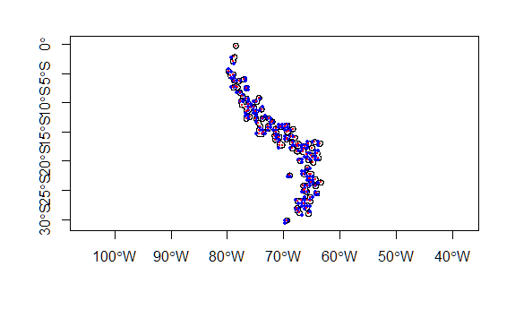

```r
points(ac, cex=0.5, pch=20, col='red')
```

Not all the pseudo absence points within the polygons. We will remove the points outside the polygons with the functions below:

```r
spxy <- SpatialPoints(xy, proj4string=CRS('+proj=longlat +datum=WGS84'))
o <- over(spxy, geometry(x))
xyInside <- xy[!is.na(o), ]
plot(pol, axes=T)
points(xy,  col='blue', cex=0.75, pch=20,) #all t
```

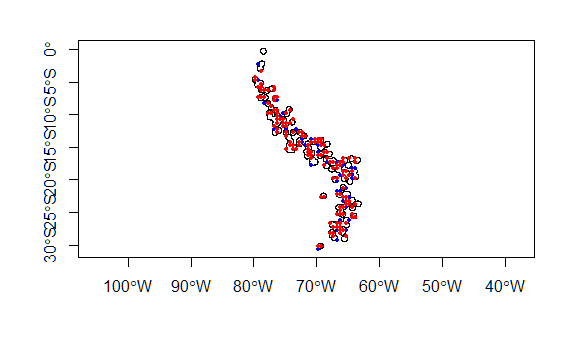

```r
points(xyInside,  col='red', cex=0.75, pch=20,)
```

## Chapter 4 Environmental data

### 4.1 Raster data covariates

There are many terms for the predictor variables in SDMs: independent variables, environmental covariates, predictors, etc.

Avoid to use ASCII because it is slow. See http://www.worldclim.org/bioclim for descriptions for bioclimatic varaibles codes.

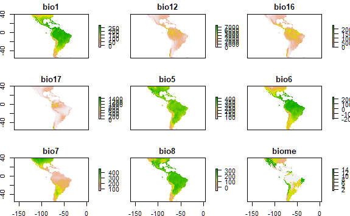

Overlay the administration boundaries and presence points:

```r
library(maptools)
data(wrld_simpl)
file <- paste(system.file(package="dismo"), "/ex/bradypus.csv", sep="")
bradypus <- read_csv(file)
# we do not need the first column
bradypus <- bradypus[,-1]
# first layer of the RasterStack
plot(predictors, 1)
# note the "add=TRUE" argument with plot
plot(wrld_simpl, add=TRUE)
```

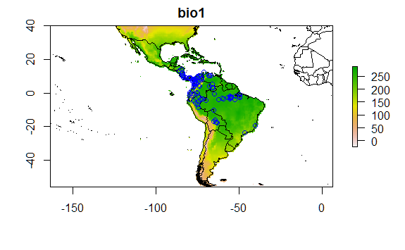

```r
# with the points function, "add" is implicit
points(bradypus, col='blue')
```

Predictor variable selection is crucial when the objective f the study is prediction. In prediction we will apply new times or places, e.g., beyond the same geographic areas.

### 4.2 Extracting values from rasters

We apply extract function to extract for the *Bradypus* occurence points and for the 500 random background points.

```r
summary(sdmdata)
```

```
       pb              bio1           bio12            bio16
 Min.   :0.0000   Min.   : -3.0   Min.   :   3.0   Min.   :   2.0
 1st Qu.:0.0000   1st Qu.:177.0   1st Qu.: 752.2   1st Qu.: 327.5
 Median :0.0000   Median :242.0   Median :1489.5   Median : 655.5
 Mean   :0.1883   Mean   :214.3   Mean   :1574.5   Mean   : 643.2
 3rd Qu.:0.0000   3rd Qu.:261.0   3rd Qu.:2250.8   3rd Qu.: 911.8
 Max.   :1.0000   Max.   :286.0   Max.   :7682.0   Max.   :2458.0

     bio17             bio5            bio6              bio7
 Min.   :   0.0   Min.   : 67.0   Min.   :-207.00   Min.   : 68.0
 1st Qu.:  37.0   1st Qu.:302.8   1st Qu.:  42.75   1st Qu.:117.0
 Median :  98.5   Median :321.0   Median : 160.00   Median :159.5
 Mean   : 159.2   Mean   :309.8   Mean   : 119.32   Mean   :190.4
 3rd Qu.: 230.5   3rd Qu.:333.2   3rd Qu.: 201.25   3rd Qu.:251.5
 Max.   :1496.0   Max.   :405.0   Max.   : 232.00   Max.   :443.0

      bio8           biome
 Min.   :-33.0   1      :280
 1st Qu.:218.8   13     : 79
 Median :250.5   7      : 63
 Mean   :225.0   8      : 52
 3rd Qu.:262.0   2      : 46
 Max.   :316.0   (Other): 95
                 NA's   :  1
```

Bioclimatic variables:

BIO1 = Annual Mean Temperature BIO5 = Max Temperature of Warmest Month BIO6 = Min Temperature of Coldest Month BIO7 = Temperature Annual Range (BIO5-BIO6) BIO8 = Mean Temperature of Wettest Quarter BIO12 = Annual Precipitation BIO16 = Precipitation of Wettest Quarter BIO17 = Precipitation of Driest Quarter

Model selection process involves a check for collinearity.

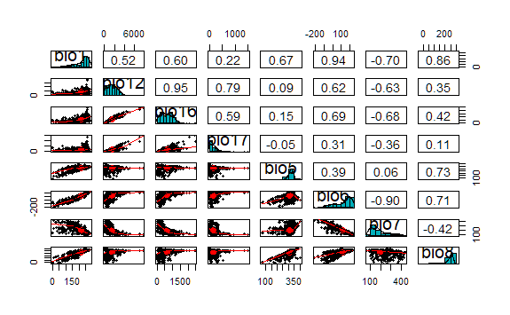

```r
# pairs plot of the values of the climate data
# at the bradypus occurrence sites.
#pairs(sdmdata[,2:5], cex=0.1, fig=TRUE)
#See Dormann et al. (2013)for a discussion of methods to remove colinearity.
##Correlation matrix; a better version than 'pairs' function
library(psych)
pairs.panels(sdmdata[,2:9],
             method = "pearson", # correlation method
             hist.col = "#00AFBB",
             density = TRUE,  # show density plots
             ellipses = TRUE # show correlation ellipses
             )
```

```r
#find variables with high correlation
library(caret)
correlated_variables<-findCorrelation(cor(sdmdata[,2:9]), cutoff = .7, exact = T, names=F)
```

“findCorrelation” suggest **bio6, bio1, bio16, bio12, bio8** is/are potentially collinear with other predictors.

## Chapter 5 Model fitting

### 5.1 Classic GLM model

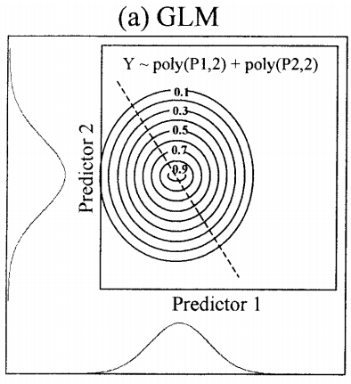

Generalized linear model with second order polynomial terms response curve used to model distribution of plants and vegetation.

```r
summary(m1)
```

```
Call:
glm(formula = pb ~ bio1 + bio5 + bio12, data = sdmdata)

Deviance Residuals:
     Min        1Q    Median        3Q       Max
-0.62298  -0.23134  -0.08801   0.08069   0.92866

Coefficients:
              Estimate Std. Error t value Pr(>|t|)
(Intercept)  1.336e-01  1.085e-01   1.232  0.21844
bio1         1.252e-03  3.877e-04   3.229  0.00131 **
bio5        -1.391e-03  4.716e-04  -2.950  0.00330 **
bio12        1.381e-04  1.689e-05   8.177 1.68e-15 ***
---
Signif. codes:  0 ‘***’ 0.001 ‘**’ 0.01 ‘*’ 0.05 ‘.’ 0.1 ‘ ’ 1

(Dispersion parameter for gaussian family taken to be 0.1187387)

    Null deviance: 94.156  on 615  degrees of freedom
Residual deviance: 72.668  on 612  degrees of freedom
AIC: 441.53

Number of Fisher Scoring iterations: 2
```

### 5.1 Classic Bioclim model

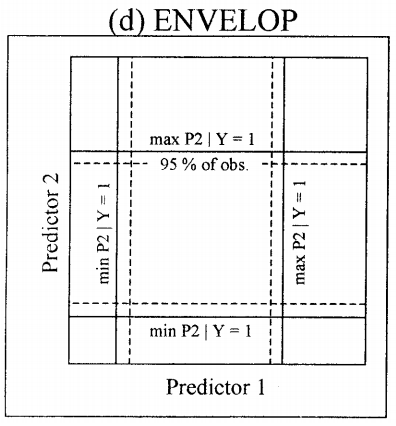

environmental envelope of the BIOCLIM type used to model distribution of plants and vegetation.

```r
bc <- bioclim(presvals[,c('bio1', 'bio5', 'bio12')])
class(bc)
```

```
[1] "Bioclim"
attr(,"package")
[1] "dismo"
```

```r
bc
```

```
class    : Bioclim

variables: bio1 bio5 bio12


presence points: 116
   bio1 bio5 bio12
1   263  338  1639
2   263  338  1639
3   253  329  3624
4   243  318  1693
5   243  318  1693
6   252  326  2501
7   240  317  1214
8   275  335  2259
9   271  327  2212
10  274  329  2233
  (... ...  ...)
```

```r
pairs(bc)
response(bc)
```

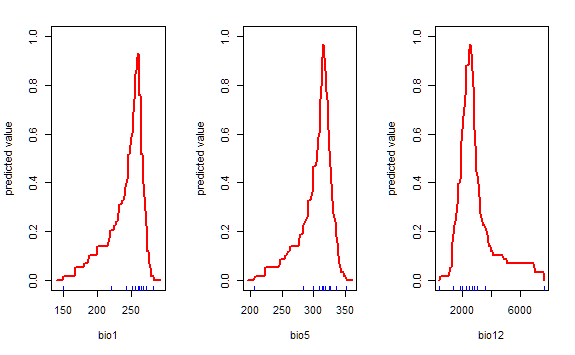

```r
#Generate response plots for each bioclimatc variable
response(bc)
```

## Chapter 6 Model prediction

Most of the purpose of SDM is to create a map of suitability scores. R can handle this easily by providing a raster object and a model object.

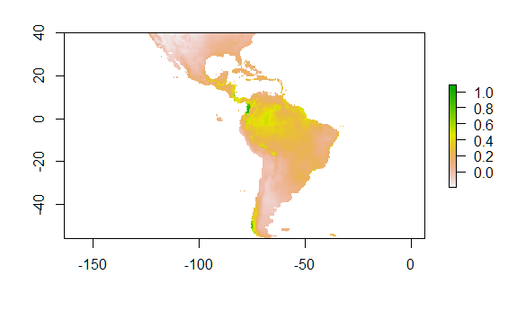

## Chapter 7 Model evaluation

Pretty much model evaluation is focused on how well the data predicts to points not used in model training (cross-validation of partitioned data, e.g., chessboard sampling). In other words, this consists of creating a model with one ’training’ data set, and testing it with another data set of known occurrences.

Some checkpoints in model evaluation includes:

1. ecologically sensible.
2. fitted functions make sense
3. reasonable predictions (pass visual and quantitative check)
4. no spatial patterns in model residuals

Meaasures for evaluation models are often ‘threshold dependent’. Values above the threshold values indicate presence and values below the threshold values indicate absence.

the Area Under the Receiver Operator Curve (AUC) is the most widely used non threshold evaluation method. AUC is a measure of rank correlation. AUC score of 0.5 means that the model is as hood as a random guess.

Here is an illustration on how AUC is computed:

We start off by generating two varaibles with random normally distributed values, but different mean and standard deviation.

```r
p <- rnorm(50, mean=0.7, sd=0.3)
a <- rnorm(50, mean=0.4, sd=0.4)
par(mfrow=c(1, 2))
plot(sort(p), col='red', pch=21)
points(sort(a), col='blue', pch=24)
```

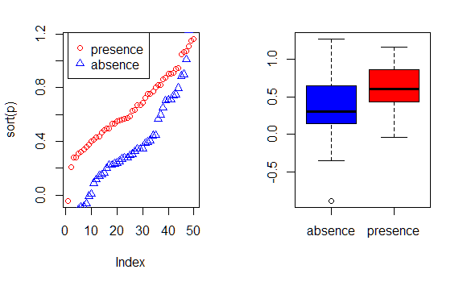

```r
legend(1, 0.95 * max(a,p), c('presence', 'absence'), pch=c(21,24), col=c('red', 'blue'))
comb = c(p,a)
group = c(rep('presence', length(p)), rep('absence', length(a)))
boxplot(comb~group, col=c('blue', 'red'))
```

Then, we compute the correlation coeeficient:

```r
group = c(rep(1, length(p)), rep(0, length(a)))
cor.test(comb, group)$estimate
```

```
      cor
0.3849284
```

```r
mv <- wilcox.test(p,a)
auc <- as.numeric(mv$statistic) / (length(p) * length(a))
auc
```

```
[1] 0.742
```

Alternatively, we can use model evaluation functions from ‘dismo’ package:

```r
e<-evaluate(p=p, a=a)
e
```

```
class          : ModelEvaluation
n presences    : 50
n absences     : 50
AUC            : 0.742
cor            : 0.3849284
max TPR+TNR at : 0.3600722
```

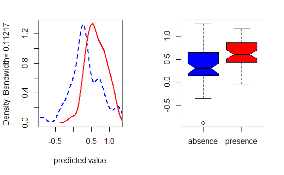

```r
par(mfrow=c(1, 2))
density(e)
boxplot(e, col=c('blue', 'red'))
```

```r
samp <- sample(nrow(sdmdata), round(0.75 * nrow(sdmdata)))
traindata <- sdmdata[samp,]
traindata <- traindata[traindata[,1] == 1, 2:9]
testdata <- sdmdata[-samp,]
bc <- bioclim(traindata)
e <- evaluate(testdata[testdata==1,], testdata[testdata==0,], bc)
e
```

```
class          : ModelEvaluation
n presences    : 27
n absences     : 127
AUC            : 0.7941091
cor            : 0.3136255
max TPR+TNR at : 0.01113596
```

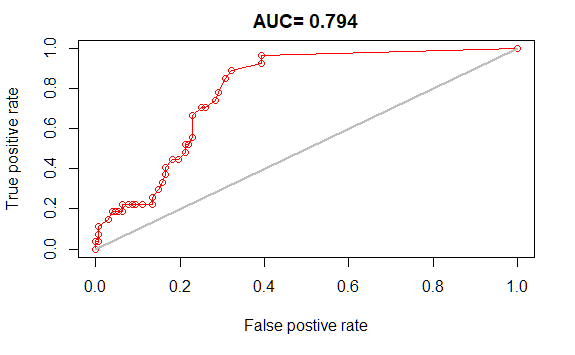

```r
plot(e, 'ROC')
```

In the presence-only data, we divide the data in two random sets, one for training the model and one for evaluating the model.

```r
e
```

[output not shown]

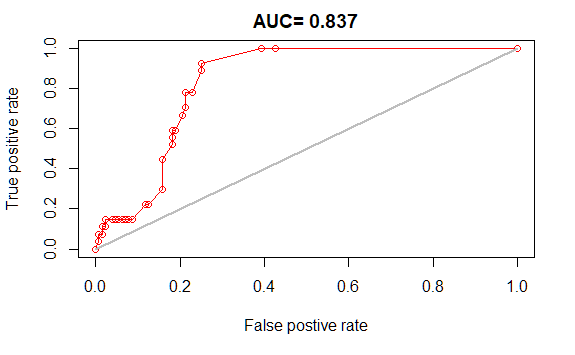

```r
plot(e, 'ROC')
```

For a more rigorous partitioning procedure, we can use k-fild data partitioning. It creates a vector that assigns each row in the data matrix to a group ( between 1 to k). In this case we use k=5 which means we can fit and tests our model five times.

```r
pres <- sdmdata[sdmdata[,1] == 1, 2:9]
back <- sdmdata[sdmdata[,1] == 0, 2:9]
k <- 5
group <- kfold(pres, k)
group[1:10]
```

```
 [1] 1 1 2 1 2 2 4 2 2 1
```

```r
e <- list()
for (i in 1:k) {
train <- pres[group != i,]
test <- pres[group == i,]
bc <- bioclim(train)
e[[i]] <- evaluate(p=test, a=back, bc)
}
```

```r
auc <- sapply( e, function(x){slot(x, 'auc')} )
auc
```

```
[1] 0.6866957 0.7322609 0.7874167 0.8059565 0.8173913
```

```r
mean(auc) #mean AUC values
```

```
[1] 0.7659442
```

```r
#the ”maximum of the sum of the sensitivity (true positive rate) and specificity (true negative rate)”
 sapply( e, function(x){ x@t[which.max(x@TPR + x@TNR)] } )
```

```
[1] 0.06441613 0.06441613 0.03250870 0.03215806 0.08592151
```

AUC indicator is highly spatial extent- sensitive. The larger the extent, the higher AUC value. In this sense, AUC values are biased and cannot be directly compared.

To resolve this problem, we can apply “point-wise distance sampling” to remove “spatial sorting bias”.

```r
nr <- nrow(bradypus)
s <- sample(nr, 0.25 * nr) #sample a quarter of presence data
pres_train <- bradypus[-s, ] # select 75% (non-s)
pres_test <- bradypus[s, ] # select the sampled data (s)
nr <- nrow(backgr)
s <- sample(nr, 0.25 * nr)
back_train <- backgr[-s, ]
back_test <- backgr[s, ]
#spatial sorting bias
sb<-ssb(pres_test, back_test, pres_train)
```

If there is no SSB, the value should be 1, SSB is very strong when the result close to zero.

```r
#point wise distance sampling
i <- pwdSample(pres_test, back_test, pres_train, n=1, tr=0.1)
pres_test_pwd <- pres_test[!is.na(i[,1]), ]
back_test_pwd <- back_test[na.omit(as.vector(i)), ]
sb2 <- ssb(pres_test_pwd, back_test_pwd, pres_train)
sb2[1]/ sb2[2]
```

```
[1] 0.9883225
```

Run the model again and evaluate the model.

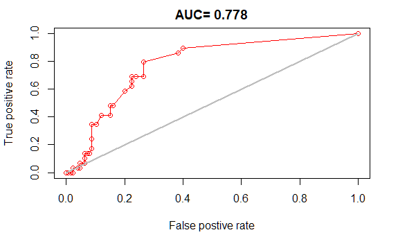

```r
bc <- bioclim(predictors, pres_train)
e<-evaluate(bc, p=pres_test, a=back_test, x=predictors)
plot(e, 'ROC')
```

## Chapter 8 Maxent

```r
install.packages(c('BIEN', 'rJava', 'maxnet'))
```

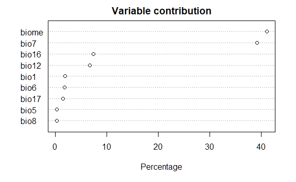

```r
jar <- paste(system.file(package="dismo"), "/java/maxent.jar", sep='')
if (file.exists(jar)) {
 xm <- maxent(predictors, as.matrix(pres_train), factors='biome')
 plot(xm)
  } else {
  cat('cannot run this example because maxent is not available')
  plot(1)
  }
```

From the plot above we can see the model is most sensitive to variation in biome (WWF ecoregion), with additional contributions from BIO7 “Temperature Annual Range (BIO5-BIO6)”, BIO 16 Precipitation of Wettest Quarter.

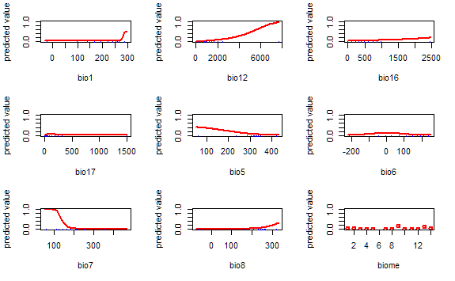

```r
if (file.exists(jar)) {
  response(xm)
  } else {
  cat('cannot run this example because maxent is not available')
  plot(1)
  }
```

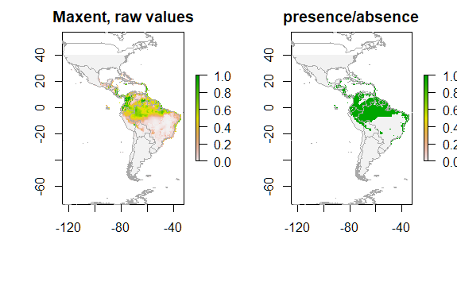

```r
 if (file.exists(jar)) {
  e <- evaluate(pres_test, back_test, xm, predictors)
  e
  px <- predict(predictors, xm, ext=extent(predictors), progress='')
  par(mfrow=c(1,2))
  plot(px, main='Maxent, raw values')
  plot(wrld_simpl, add=TRUE, border='dark grey')
  tr <- threshold(e, 'spec_sens')
  plot(px > tr, main='presence/absence')
  plot(wrld_simpl, add=TRUE, border='dark grey')
  points(pres_train, pch=' ')
  } else {
  plot(1)
  }
```

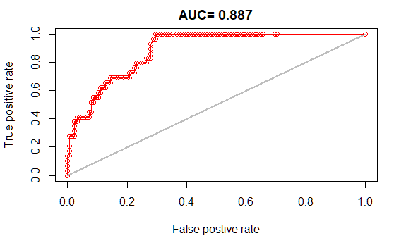

```r
plot(e, 'ROC')
```